# R Notebook

# 8.16.7 quick plots

we can use *qplot* to make histograms, density plots, boxplot, qqplots and more. although it not provide the level of control of *ggplot*, *qplot* is definitely useful as it permits us to make a plot with a short snippet of code.

suppose we have the female heights in an object x:

```r
x<- heights %>% filter(sex == "Female") %>% pull(height)
```

to make a quick histogram we can use:

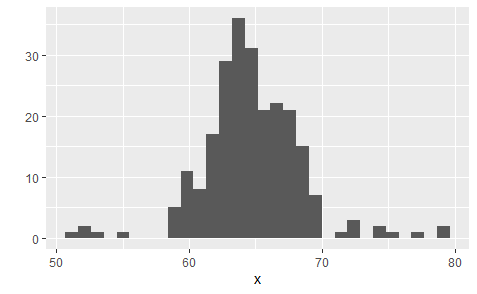

```r
qplot(x)
```

the fraction guesses that we want to make a histogram because we only supplied one variable. we saw that if we supply *qplot* two variables, it automatically makes a scatterplot. to make a quick qqplot you have to use the sample argument. note that we can add layers just as we do with ggplot.

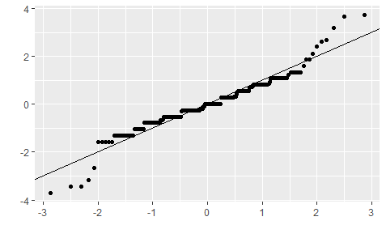

```r
qplot(sample= scale(x))+geom_abline()
```

if we supply a factor and a numeric vector, we obtain a plot like the one below. note that in the code below we are using the *data* argument. because the data frame is not the first argument in *qplot*. we have to use the dot operator.

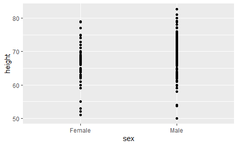

```r
heights %>% qplot(sex, height, data = .)
```

we can also select a specific geometry by using the *geom* argument. so to convert the plot above boxplot, we use the following code:

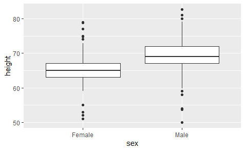

```r
heights %>% qplot(sex, height, data=., geom= "boxplot")
```

we can also use the *geom* argument to generate a density plot instead of a histogram:

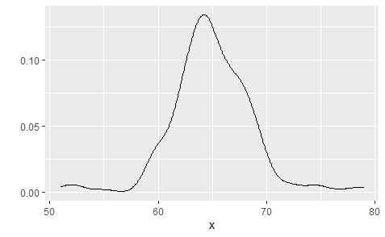

```r
qplot(x, geom = "density")
```

although not as much as with *ggplot*, we do have some flexibility to improve the results of *qplot*. looking at the help file we see several ways in which we can improve the look of the histogram above. here is an example:

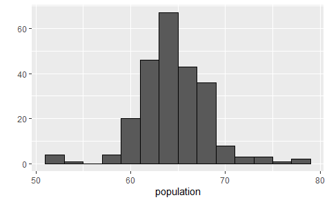

```r
qplot(x, bins=15, color=I("black"), xlab = "population")
```

note: the reason we use *I(“black”)* is because we want *qplot* to treat *“black”* as a character rather than convert it to a factor, which is the default behavior within *aes*, which is internally called here. in general, the function *I* is used in R to say “keep it as it is”.

# 8.17 exercises

1. now we are going to use the *geom_histogram* function to make a histogram of the heights in the *height* data frame. when reading the documentation for this function we see that it requires just one mapping, the values to be used for the histogram. make a histogram of all the plots. what is the variable containing the heights? answer: d
2. now create a ggplot abject using the pipe to assign the heights data to a ggplot abject.

```
heights %>% ggplot(aes(height))
```

3. now we are ready to add a layer to actually make the histogram. use the object created in the previous exercise and the *geom_histogram* function to make the histogram.

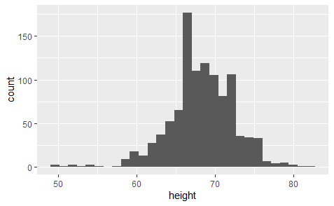

```r
heights %>% ggplot(aes(height)) +geom_histogram()
```

4. note that when we run the code in the previous exercise we got the warning. use the binwidth argument to change the histogram made in the previous exercise to use bins of size 1 inch.

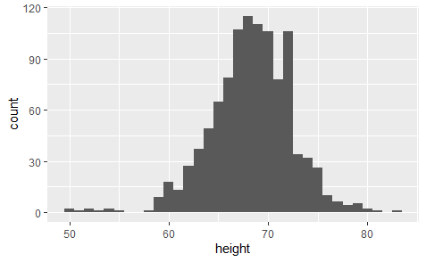

```r
heights %>% ggplot(aes(height))+ geom_histogram(binwidth = 1)
```

5. instead of a histogram, we are going to make a smooth density plot. in this case we will not make an object, but instead render the plot with one line of coed. change the geometry in the code previously used to make a smooth density instead of histogram.

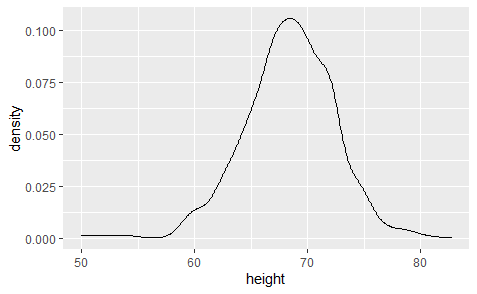

```r
heights %>% ggplot(aes(height))+geom_density()
```

6. now we are going to make a density plot for males and females separately. we can do this using the *group* argument. we assign groups via the aesthetic mapping as each point needs to a group before making the calculations needed to estimate a density.

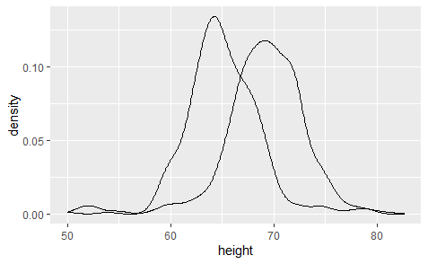

```r
heights %>% ggplot(aes(x=height, group = sex))+geom_density()
```

7. we can also assign groups through the *color* argument. this has the added benefit that it uses to distinguish the groups. change the code above to use color.

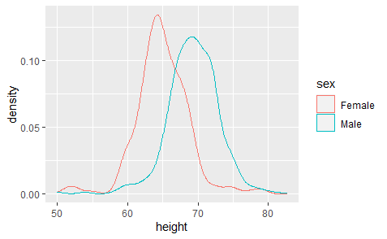

```r
heights %>% ggplot(aes(height, group=sex, col=sex))+geom_density()
```

8. we can also assign groups through the *fill* argument. this has the added benefit that it uses colors to distinguish the groups, like this. however, here the second density is drawn over the other. we can make the curves more visible by using alpha blending to add transparency. set the alpha parameter to 0.2 in the *geom_density* function to make this change.

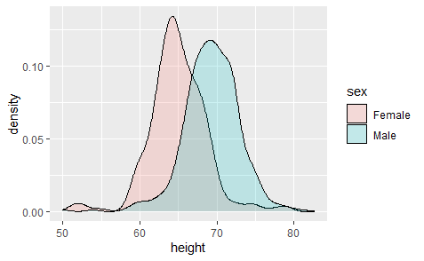

```r
heights %>% ggplot(aes(height, fill=sex))+geom_density(alpha=0.2)
```